# chapter6.Rmd

### Next we are going to standardize the variables.

```r
library(dplyr)
library(tidyr)
library(ggplot2)
```

```r
RATSL <- RATSL %>%
  group_by(Time) %>%
  mutate(stdrats = (Weight - mean(Weight))/sd(Weight)) %>%
  ungroup()
```

Now we have standardized the data by the variable weight.

##Let’s glimpse at the data

```r
glimpse(RATSL)
```

```
## Observations: 176
## Variables: 6
## $ ID      <fct> 1, 2, 3, 4, 5, 6, 7, 8, 9, 10, 11, 12, 13, 14, 15, 16, 1…
## $ Group   <fct> 1, 1, 1, 1, 1, 1, 1, 1, 2, 2, 2, 2, 3, 3, 3, 3, 1, 1, 1,…
## $ WD      <chr> "WD1", "WD1", "WD1", "WD1", "WD1", "WD1", "WD1", "WD1", …
## $ Weight  <int> 240, 225, 245, 260, 255, 260, 275, 245, 410, 405, 445, 5…
## $ Time    <int> 1, 1, 1, 1, 1, 1, 1, 1, 1, 1, 1, 1, 1, 1, 1, 1, 8, 8, 8,…
## $ stdrats <dbl> -1.0011429, -1.1203857, -0.9613953, -0.8421525, -0.88190…
```

Now you can see the standardised variable here in the data. So we succeeded on what we were trying to do.

Let’s draw the plot again with the standardised variable.

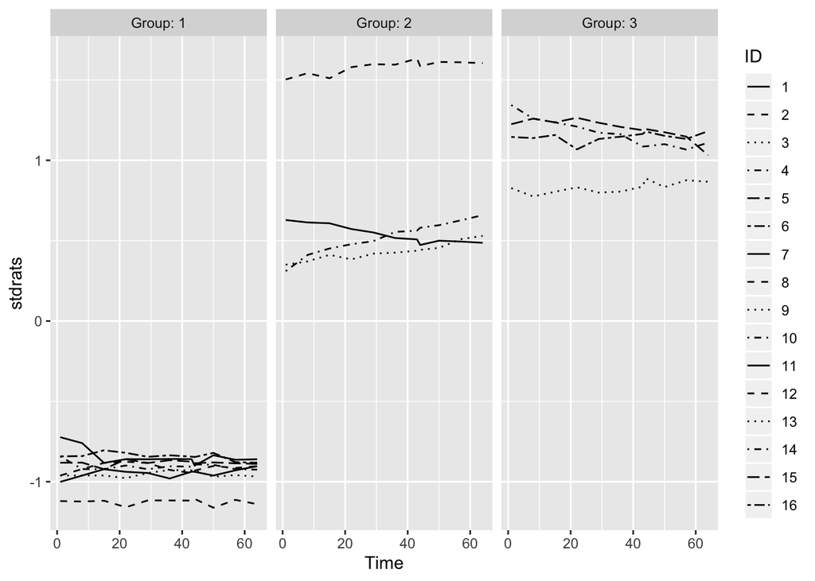

```r
ggplot(RATSL, aes(x = Time, y = stdrats, linetype = ID)) +
  geom_line() +
  scale_linetype_manual(values = rep(1:10, times=4)) +
  facet_grid(. ~ Group, labeller = label_both) +
  scale_y_continuous(name = "stdrats")
```

Now here are the figures with standardised values of the weight. The group 1 is very different from the groups 2 and 3. These rats starting weight was clearly lower than in groups 2 and 3 and the weight gain doesn’t change the standardized weight of these rats.

```r
head(RATS)
```

```
##   ID Group WD1 WD8 WD15 WD22 WD29 WD36 WD43 WD44 WD50 WD57 WD64
## 1  1     1 240 250  255  260  262  258  266  266  265  272  278
## 2  2     1 225 230  230  232  240  240  243  244  238  247  245
## 3  3     1 245 250  250  255  262  265  267  267  264  268  269
## 4  4     1 260 255  255  265  265  268  270  272  274  273  275
## 5  5     1 255 260  255  270  270  273  274  273  276  278  280
## 6  6     1 260 265  270  275  275  277  278  278  284  279  281
```

```r
head(RATSL)
```

```
## # A tibble: 6 x 6
##   ID    Group WD    Weight  Time stdrats
##   <fct> <fct> <chr>  <int> <int>   <dbl>
## 1 1     1     WD1      240     1  -1.00
## 2 2     1     WD1      225     1  -1.12
## 3 3     1     WD1      245     1  -0.961
## 4 4     1     WD1      260     1  -0.842
## 5 5     1     WD1      255     1  -0.882
## 6 6     1     WD1      260     1  -0.842
```

I used the head command just to look at these two datasets again.

#Now were are going to look at the number of weekdays

```r
n <- RATSL$Time %>% unique() %>% length()
```

#Next we are going to look at the summary data with mean and standard error of weight by group and time

```r
RATSS <- RATSL %>%
  group_by(Group, Time) %>%
  summarise(mean = mean(Weight), se = sd(Weight)/sqrt(n)) %>%
  ungroup()
```

```r
glimpse(RATSS)
```

```
## Observations: 33
## Variables: 4
## $ Group <fct> 1, 1, 1, 1, 1, 1, 1, 1, 1, 1, 1, 2, 2, 2, 2, 2, 2, 2, 2, 2…
## $ Time  <int> 1, 8, 15, 22, 29, 36, 43, 44, 50, 57, 64, 1, 8, 15, 22, 29…
## $ mean  <dbl> 250.625, 255.000, 254.375, 261.875, 264.625, 265.000, 267.…
## $ se    <dbl> 4.589478, 3.947710, 3.460116, 4.100800, 3.333956, 3.552939…
```

##Next we are going to plot the mean profiles

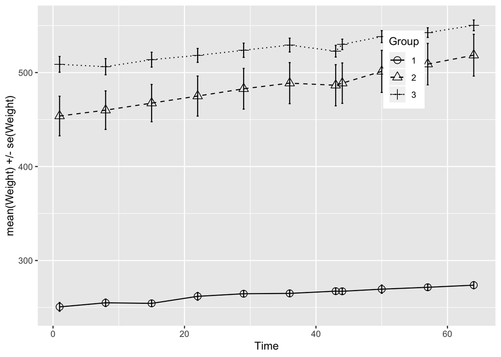

```r
ggplot(RATSS, aes(x = Time, y = mean, linetype = Group, shape = Group)) +
  geom_line() +
  scale_linetype_manual(values = c(1,2,3)) +
  geom_point(size=3) +
  scale_shape_manual(values = c(1,2,3)) +
  geom_errorbar(aes(ymin = mean -se, ymax = mean +se, linetype = "1"), width=0.3) +
  theme(legend.position = c(0.8,0.8)) +
  scale_y_continuous(name = "mean(Weight) +/- se(Weight)")
```

```r
RATSL8S <- RATSL %>%
  filter(Time>1) %>%
  group_by(ID, Group) %>%
  summarise(mean = mean(Weight)) %>%
  ungroup()
```

```r
glimpse(RATSL8S)
```

```
## Observations: 16
## Variables: 3
## $ ID    <fct> 1, 2, 3, 4, 5, 6, 7, 8, 9, 10, 11, 12, 13, 14, 15, 16
## $ Group <fct> 1, 1, 1, 1, 1, 1, 1, 1, 2, 2, 2, 2, 3, 3, 3, 3
## $ mean  <dbl> 263.2, 238.9, 261.7, 267.2, 270.9, 276.2, 274.6, 267.5, 44…
```

#Draw a boxplot

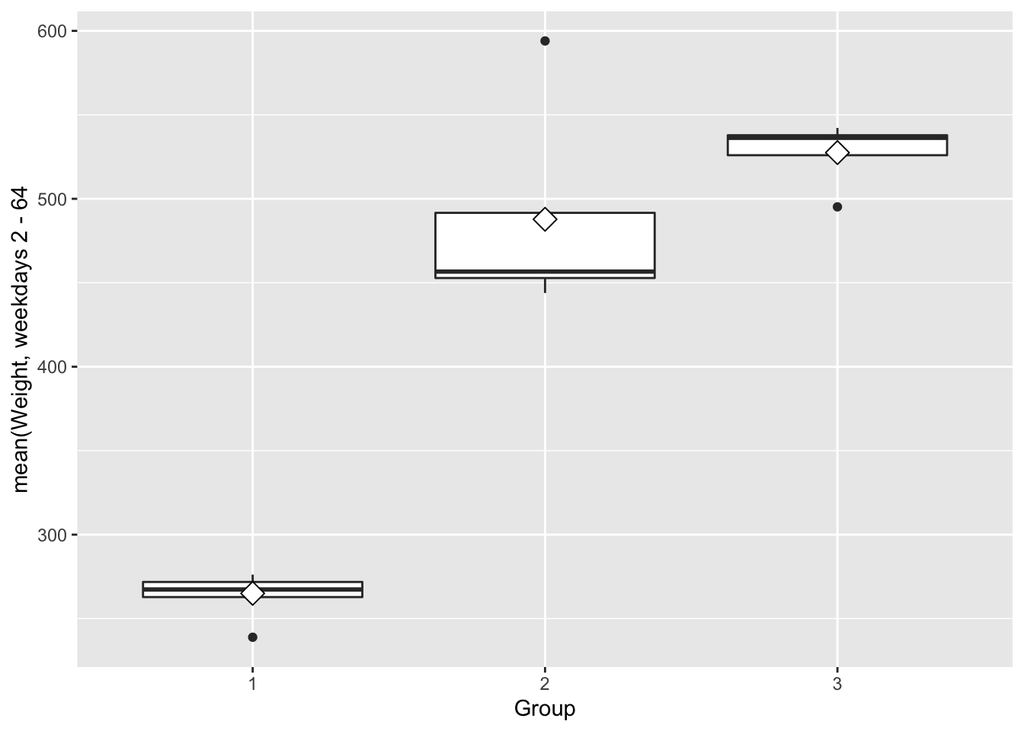

```r
ggplot(RATSL8S, aes(x = Group, y = mean)) +
  geom_boxplot() +
  stat_summary(fun.y = "mean", geom = "point", shape=23, size=4, fill = "white") +
  scale_y_continuous(name = "mean(Weight, weekdays 2 - 64")
```

From this picture you can see that each group contains individuals who are fare from the box. They are so called outliers and these kind of observations are usually taken away from the analysis so that they don’t alter the results too much.

#Create a new data by filtering the outliers and adjust the ggplot code the draw the plot again with the new data. Next I am going to take the outliers away from the analysis and then draw the picture again.

```r
RATSL8S1 <- RATSL8S %>%
  filter(mean < 550, mean > 250, mean != 495.2)
```

Drawing the picture again

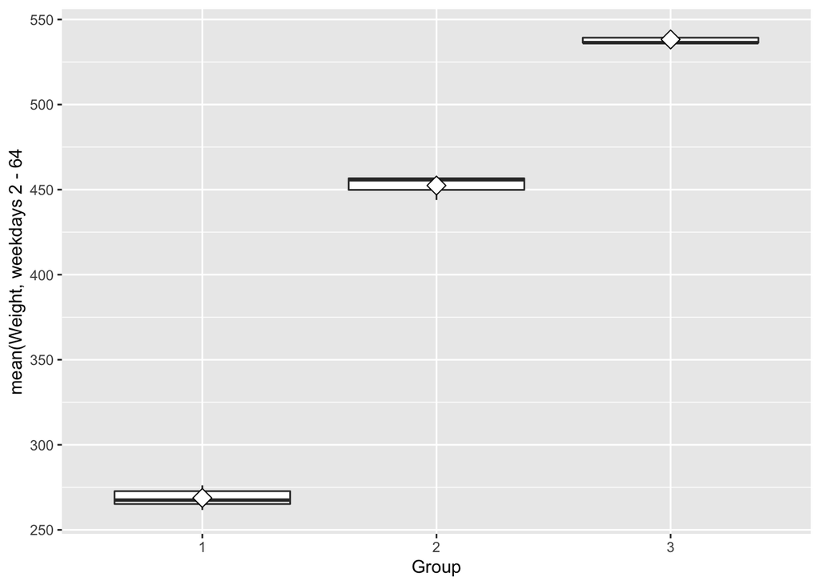

```r
ggplot(RATSL8S1, aes(x = Group, y = mean)) +
  geom_boxplot() +
  stat_summary(fun.y = "mean", geom = "point", shape=23, size=4, fill = "white") +
  scale_y_continuous(name = "mean(Weight, weekdays 2 - 64")
```

As you can see, now the outliers are gone and the boxes look like this. Again you can see that group 1 differs quite a lot from group 2 and 3.

# Perform a two-sample t-test.

In the datacamp we did an exercise where we used the two-sample t-test to the BPRSL data. As you can see from below we cannot do the t-test to the RATSL data because it has 3 different “treatment” groups.

```r
names(RATSL8S1)
```

```
## [1] "ID"    "Group" "mean"
```

```r
library(dplyr)
library(tidyr)
library(ggplot2)
```

#Next I tried to do the t-test to the data, but it was impossible, because there are 3 groups and t-test is used only when comparing 2 groups means to each other to see is there any difference or not. If there would be only 2 groups, you could use the command as below.

t.test(mean, Weight, data = RATSL8S1)

# Next were are going to add the baseline from the original data as a new variable to the summary data.

```r
RATSL8S2 <- RATSL8S %>%
  mutate(baseline = RATS$WD1)
```

# We are going to fit the linear model with the mean as the response.

```r
names(RATSL8S2)
```

```
## [1] "ID"       "Group"    "mean"     "baseline"
```

Now let’s do the fit linear model.

```r
fit <- lm(mean ~ baseline + Group, data = RATSL8S2)
summary(fit)
```

```
##
## Call:
## lm(formula = mean ~ baseline + Group, data = RATSL8S2)
##
## Residuals:
##     Min      1Q  Median      3Q     Max
## -23.905  -4.194   2.190   7.577  14.800
##
## Coefficients:
##             Estimate Std. Error t value Pr(>|t|)
## (Intercept) 33.16375   21.87657   1.516   0.1554
## baseline     0.92513    0.08572  10.793 1.56e-07 ***
## Group2      34.85753   18.82308   1.852   0.0888 .
## Group3      23.67526   23.25324   1.018   0.3287
## ---
## Signif. codes:  0 '***' 0.001 '**' 0.01 '*' 0.05 '.' 0.1 ' ' 1
##
## Residual standard error: 11.68 on 12 degrees of freedom
## Multiple R-squared:  0.9936, Adjusted R-squared:  0.992
## F-statistic: 622.1 on 3 and 12 DF,  p-value: 1.989e-13
```

#Next we are going to compute the analysis of variance table for the fitted model with anova().

```r
anova(fit)
```

```
## Analysis of Variance Table
##
## Response: mean
##           Df Sum Sq Mean Sq   F value   Pr(>F)
## baseline   1 253625  253625 1859.8201 1.57e-14 ***
## Group      2    879     439    3.2219  0.07586 .
## Residuals 12   1636     136
## ---
## Signif. codes:  0 '***' 0.001 '**' 0.01 '*' 0.05 '.' 0.1 ' ' 1
```

This analysis shows that there is a statistical difference between these groups based on the starting weight of these rats. So the baseline group also known as the starting weight of the rats is statistically significant. It is quite understandable, so if the starting weight is higher the rat will weigh more in the end of the study. So it can be so that the starting weight affects more to the end weight than the diet these rats received.

##Then we are going to do next analysis to the BPRS data. Remember that we have to first change the factor variables and then add the week variable to the dataset and also convert the dataset into a long form. ##Impelement the analyses of Chapter 9 of MABS using the BPRS data.

```r
library(dplyr)
library(tidyr)
library(ggplot2)
```

First let’s read the dataset.

```r
BPRS <- read.csv("BPRS.csv", header = TRUE, sep = ",")
```

Then we are going to change the factor variables.

```r
BPRS$treatment <- factor(BPRS$treatment)
BPRS$subject <- factor(BPRS$subject)
#And then we are going to add a week variable to BPRS and convert it to a long form.
BPRSL <-  BPRS %>% gather(key = weeks, value = bprs, -treatment, -subject)
```

I didn’t know for sure do you need to extract the week number from the dataset but I did it because it was done in the exercises in the datacamp.

```r
# Extract the week number
BPRSL <-  BPRSL %>% mutate(week = as.integer(substr(weeks,5,5)))
```

Let’s look at the BPRSL data. You can use the glimpse and names or heads command to look at the dataset. Also commands view and str can be used for this function.

```r
glimpse(BPRSL)
```

```
## Observations: 360
## Variables: 5
## $ treatment <fct> 1, 1, 1, 1, 1, 1, 1, 1, 1, 1, 1, 1, 1, 1, 1, 1, 1, 1, …
## $ subject   <fct> 1, 2, 3, 4, 5, 6, 7, 8, 9, 10, 11, 12, 13, 14, 15, 16,…
## $ weeks     <chr> "week0", "week0", "week0", "week0", "week0", "week0", …
## $ bprs      <int> 42, 58, 54, 55, 72, 48, 71, 30, 41, 57, 30, 55, 36, 38…
## $ week      <int> 0, 0, 0, 0, 0, 0, 0, 0, 0, 0, 0, 0, 0, 0, 0, 0, 0, 0, …
```

```r
names(BPRSL)
```

```
## [1] "treatment" "subject"   "weeks"     "bprs"      "week"
```

As you can see the BPRSL dataset has 360 observations of 5 variables. The end lines shows the names of the variables.

I also did the number of weeks, baseline (week 0) included, bacause it was done in the datacamp exercise.

```r
n <- BPRSL$week %>% unique() %>% length()
```

I used the commands names and glimpse because I wanted to look at the BPRSl dataset.

```r
names(BPRSL)
```

```
## [1] "treatment" "subject"   "weeks"     "bprs"      "week"
```

```r
glimpse(BPRSL)
```

```
## Observations: 360
## Variables: 5
## $ treatment <fct> 1, 1, 1, 1, 1, 1, 1, 1, 1, 1, 1, 1, 1, 1, 1, 1, 1, 1, …
## $ subject   <fct> 1, 2, 3, 4, 5, 6, 7, 8, 9, 10, 11, 12, 13, 14, 15, 16,…
## $ weeks     <chr> "week0", "week0", "week0", "week0", "week0", "week0", …
## $ bprs      <int> 42, 58, 54, 55, 72, 48, 71, 30, 41, 57, 30, 55, 36, 38…
## $ week      <int> 0, 0, 0, 0, 0, 0, 0, 0, 0, 0, 0, 0, 0, 0, 0, 0, 0, 0, …
```

###Next we are going to draw a plot of the data. I first draw the plot of the data as it was done in the datacamp.

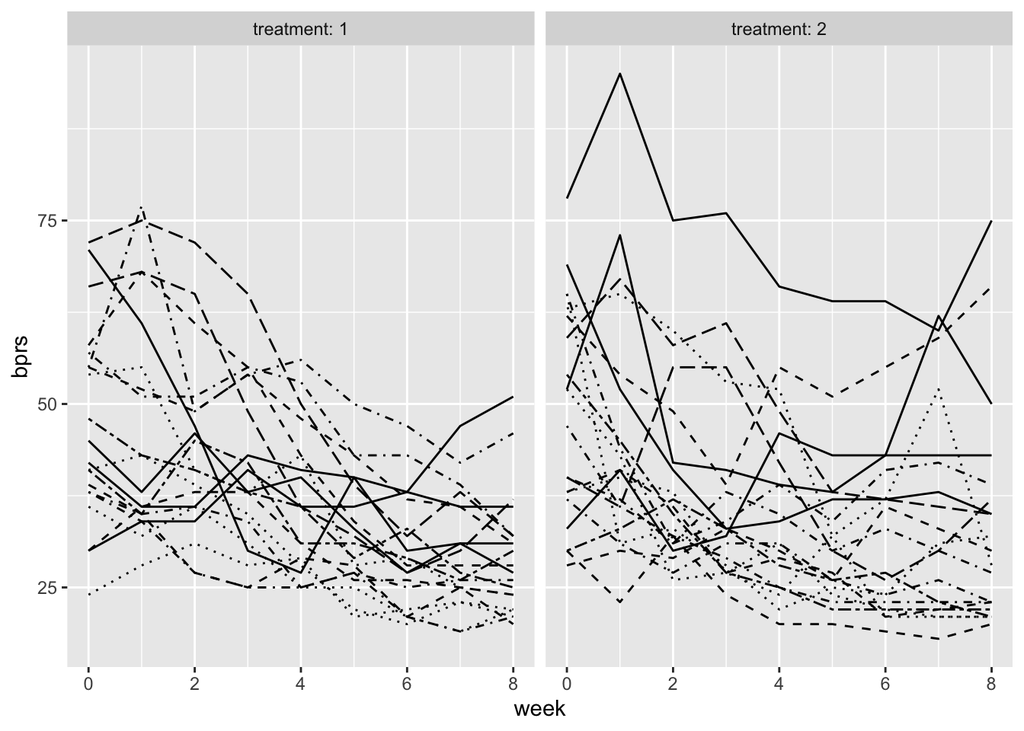

```r
ggplot(BPRSL, aes(x = week, y = bprs, linetype = subject)) +
  geom_line() +
  scale_linetype_manual(values = rep(1:10, times=4)) +
  facet_grid(. ~ treatment, labeller = label_both) +
  theme(legend.position = "none") +
  scale_y_continuous(limits = c(min(BPRSL$bprs), max(BPRSL$bprs)))
```

The BPRS data consisted of 40 male subjects randomly assigned to one of two treatment groups and each subject was rated on the brief psychiatric rating scale (BPRS) measured before treatment began (week 0) and then at weekly intervals for eight weeks. The BPRS assesses the level of 18 symptom constructs such as hostility, suspiciousness, hallucinations and grandiosity; each of these is rated from one (not present) to seven(extremely severe). As you can see from the picture there are 2 treatment groups. The study subjects were treated for 8 weeks, and you can see how the brps evolves in each subject during these 8 weeks. For me it is hard to see is there a clear difference between these 2 treatment groups because for the majority the bprs is dropping in these 8 weeks in both treatment groups.

First I tried to do the picture with this code below.

ggplot(BPRSL, aes(x = weeks, y = bprs, group = subject)) + geom_line(aes(linetype = treatment)) + geom_point(aes(weeks, bprs, color = subject)) scale_x_continuous(name = “Weeks”, breaks = seq(0, 8)) + scale_y_continuous(name = “bprs”) + theme(legend.position = “top”)

I first tried to draw the picture like it was done with the RATS data. Unfortunately I always got this error message. “Error: geom_path: If you are using dotted or dashed lines, colour, size and linetype must be constant over the line”. Then I tried to find a solution for this error and I ended up using this code I found geom_step. After that I could draw the picture, but unfortunately I cannot interpret it.

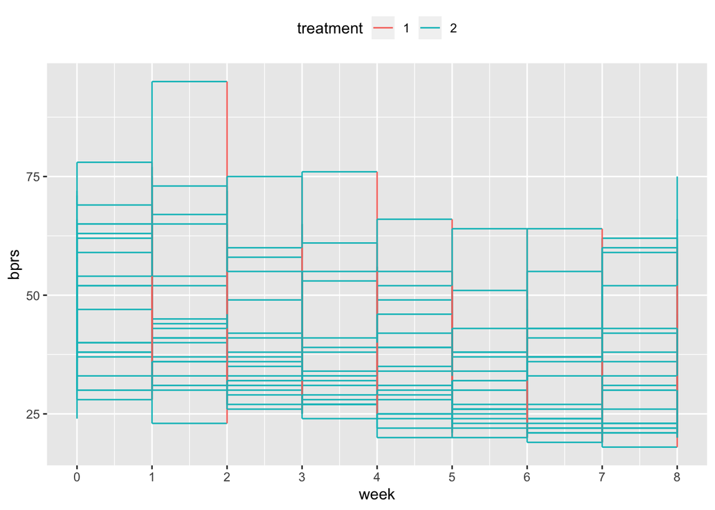

```r
ggplot(data = BPRSL) +
  geom_step(aes(x = week, y = bprs, group = subject, color = treatment)) +
  scale_x_continuous(name = "week", breaks = seq(0, 8)) +
  scale_y_continuous(name = "bprs") +
  theme(legend.position = "top")
```

## Next we are going to create a regression model of the data called BPRS_reg.

First I wanted to look at the variable names of BPRS data and BPRSL data, so I used the commands names.

```r
names(BPRS)
```

```
##  [1] "treatment" "subject"   "week0"     "week1"     "week2"
##  [6] "week3"     "week4"     "week5"     "week6"     "week7"
## [11] "week8"
```

```r
names(BPRSL)
```

```
## [1] "treatment" "subject"   "weeks"     "bprs"      "week"
```

To do the next analysis we first need to enter fwe libraries as seen below.

```r
library(tidyr)
library(dplyr)
library(lme4)
```

Now we are going to do the regression model of the data.

```r
BPRS_reg <- lm(bprs ~ weeks + treatment, data = BPRSL)
```

# Then we are going to print out a summary of the model.

```r
summary(BPRS_reg)
```

```
##
## Call:
## lm(formula = bprs ~ weeks + treatment, data = BPRSL)
##
## Residuals:
##     Min      1Q  Median      3Q     Max
## -23.714  -9.226  -2.989   6.786  48.389
##
## Coefficients:
##             Estimate Std. Error t value Pr(>|t|)
## (Intercept)  47.7139     2.0590  23.173  < 2e-16 ***
## weeksweek1   -1.6750     2.7624  -0.606  0.54467
## weeksweek2   -6.3000     2.7624  -2.281  0.02317 *
## weeksweek3   -8.8500     2.7624  -3.204  0.00148 **
## weeksweek4  -11.6500     2.7624  -4.217 3.15e-05 ***
## weeksweek5  -15.4500     2.7624  -5.593 4.51e-08 ***
## weeksweek6  -16.7750     2.7624  -6.073 3.28e-09 ***
## weeksweek7  -15.8000     2.7624  -5.720 2.29e-08 ***
## weeksweek8  -16.5750     2.7624  -6.000 4.92e-09 ***
## treatment2    0.5722     1.3022   0.439  0.66063
## ---
## Signif. codes:  0 '***' 0.001 '**' 0.01 '*' 0.05 '.' 0.1 ' ' 1
##
## Residual standard error: 12.35 on 350 degrees of freedom
## Multiple R-squared:  0.2026, Adjusted R-squared:  0.182
## F-statistic: 9.878 on 9 and 350 DF,  p-value: 1.62e-13
```

#Next we are going to create a random intercept model. So that we can create a random intercept model, we need to access library lme.

```r
library(lme4)
```

#Next we are going to create a random intercept model called BPRS_ref.

```r
BPRS_ref <- lmer(bprs ~ week + treatment + (1 | subject  ), data = BPRSL, REML = FALSE)
```

#Next we are going to print out the summary of the model.

```r
summary(BPRS_ref)
```

```
## Linear mixed model fit by maximum likelihood  ['lmerMod']
## Formula: bprs ~ week + treatment + (1 | subject)
##    Data: BPRSL
##
##      AIC      BIC   logLik deviance df.resid
##   2748.7   2768.1  -1369.4   2738.7      355
##
## Scaled residuals:
##     Min      1Q  Median      3Q     Max
## -3.0481 -0.6749 -0.1361  0.4813  3.4855
##
## Random effects:
##  Groups   Name        Variance Std.Dev.
##  subject  (Intercept)  47.41    6.885
##  Residual             104.21   10.208
## Number of obs: 360, groups:  subject, 20
##
## Fixed effects:
##             Estimate Std. Error t value
## (Intercept)  46.4539     1.9090  24.334
## week         -2.2704     0.2084 -10.896
## treatment2    0.5722     1.0761   0.532
##
## Correlation of Fixed Effects:
##            (Intr) week
## week       -0.437
## treatment2 -0.282  0.000
```

Let’s look at the summary table together. From here we can get an estimate of the variance explained by the random effect. This number is important, because if it’s indistinguishable from zero, then the random effect probably doesn’t matter and we can go ahead and do a regular linear model instead. Next we have estimates of the fixed effects, with standard errors and the t-values. And at last we have the correlation of fixed effects.

# Next we are going to create a random intercept and random slope model.

```r
BPRS_ref1 <- lmer(bprs ~ week + treatment + (week | subject), data = BPRSL, REML = FALSE)
```

# Next we are going to print a summary of the model.

```r
summary(BPRS_ref1)
```

```
## Linear mixed model fit by maximum likelihood  ['lmerMod']
## Formula: bprs ~ week + treatment + (week | subject)
##    Data: BPRSL
##
##      AIC      BIC   logLik deviance df.resid
##   2745.4   2772.6  -1365.7   2731.4      353
##
## Scaled residuals:
##     Min      1Q  Median      3Q     Max
## -2.8919 -0.6194 -0.0691  0.5531  3.7977
##
## Random effects:
##  Groups   Name        Variance Std.Dev. Corr
##  subject  (Intercept) 64.8222  8.0512
##           week         0.9609  0.9803   -0.51
##  Residual             97.4304  9.8707
## Number of obs: 360, groups:  subject, 20
##
## Fixed effects:
##             Estimate Std. Error t value
## (Intercept)  46.4539     2.1052  22.066
## week         -2.2704     0.2977  -7.626
## treatment2    0.5722     1.0405   0.550
##
## Correlation of Fixed Effects:
##            (Intr) week
## week       -0.582
## treatment2 -0.247  0.000
```

I am not sure how to interpet the t-values, because they are not the same as p-values. I don’t know for sure how to look at the statistical meaning of this summary table, so I am not going to try.

# Next we are going to perform an ANOVA test on the two models.

```r
anova(BPRS_ref1, BPRS_ref)
```

```
## Data: BPRSL
## Models:
## BPRS_ref: bprs ~ week + treatment + (1 | subject)
## BPRS_ref1: bprs ~ week + treatment + (week | subject)
##           Df    AIC    BIC  logLik deviance  Chisq Chi Df Pr(>Chisq)
## BPRS_ref   5 2748.7 2768.1 -1369.4   2738.7
## BPRS_ref1  7 2745.4 2772.6 -1365.7   2731.4 7.2721      2    0.02636 *
## ---
## Signif. codes:  0 '***' 0.001 '**' 0.01 '*' 0.05 '.' 0.1 ' ' 1
```

# Next we are going to create a random intercept and random slope model.

```r
BPRS_ref2 <- lmer(bprs ~ week * treatment + (week| subject), data = BPRSL, REML = FALSE)
```

# Next we are going to print a summary of the model.

```r
summary(BPRS_ref2)
```

```
## Linear mixed model fit by maximum likelihood  ['lmerMod']
## Formula: bprs ~ week * treatment + (week | subject)
##    Data: BPRSL
##
##      AIC      BIC   logLik deviance df.resid
##   2744.3   2775.4  -1364.1   2728.3      352
##
## Scaled residuals:
##     Min      1Q  Median      3Q     Max
## -3.0512 -0.6271 -0.0768  0.5288  3.9260
##
## Random effects:
##  Groups   Name        Variance Std.Dev. Corr
##  subject  (Intercept) 64.9964  8.0620
##           week         0.9687  0.9842   -0.51
##  Residual             96.4707  9.8220
## Number of obs: 360, groups:  subject, 20
##
## Fixed effects:
##                 Estimate Std. Error t value
## (Intercept)      47.8856     2.2521  21.262
## week             -2.6283     0.3589  -7.323
## treatment2       -2.2911     1.9090  -1.200
## week:treatment2   0.7158     0.4010   1.785
##
## Correlation of Fixed Effects:
##             (Intr) week   trtmn2
## week        -0.650
## treatment2  -0.424  0.469
## wek:trtmnt2  0.356 -0.559 -0.840
```

I don’t know how to interpret this table.

# Next we are going to perform an ANOVA test on the two models.

```r
anova(BPRS_ref2, BPRS_ref1)
```

```
## Data: BPRSL
## Models:
## BPRS_ref1: bprs ~ week + treatment + (week | subject)
## BPRS_ref2: bprs ~ week * treatment + (week | subject)
##           Df    AIC    BIC  logLik deviance  Chisq Chi Df Pr(>Chisq)
## BPRS_ref1  7 2745.4 2772.6 -1365.7   2731.4
## BPRS_ref2  8 2744.3 2775.4 -1364.1   2728.3 3.1712      1    0.07495 .
## ---
## Signif. codes:  0 '***' 0.001 '**' 0.01 '*' 0.05 '.' 0.1 ' ' 1
```

When looking at the comparison of these two models, I think no statistical significant difference is seen, becauset the Pr(>Chisq) is 0.07495, if I interpret this correctly.

# Next we are going to draw the plot of BPRSL.

Again the same error occurs. Error: geom_path: If you are using dotted or dashed lines, colour, size and linetype must be constant over the line.

ggplot(BPRSL, aes(x = week, y = bprs, group = subject)) + geom_line(aes(linetype = treatment)) + scale_x_continuous(name = “Weeks”, breaks = seq(0, 8)) + scale_y_continuous(name = “bprs”) + theme(legend.position = “top”) I tried the same code again. Not even trying to use a different code.

# Next we are going to create a vector of the fitted values.

```r
Fitted <- fitted(BPRS_ref2)
```

# Next we are going to create a new column fitted to BPRSL.

```r
BPRSL <- BPRSL %>%
  mutate(Fitted)
```

# Next we are going to draw the plot of BPRSL.

I draw the picture of the fitted data using the same code I did before so that the error-message wouldn’t come again. I can draw the picture with this geom_step command, but I cannot interpret the results. It all looks very confusing to me.

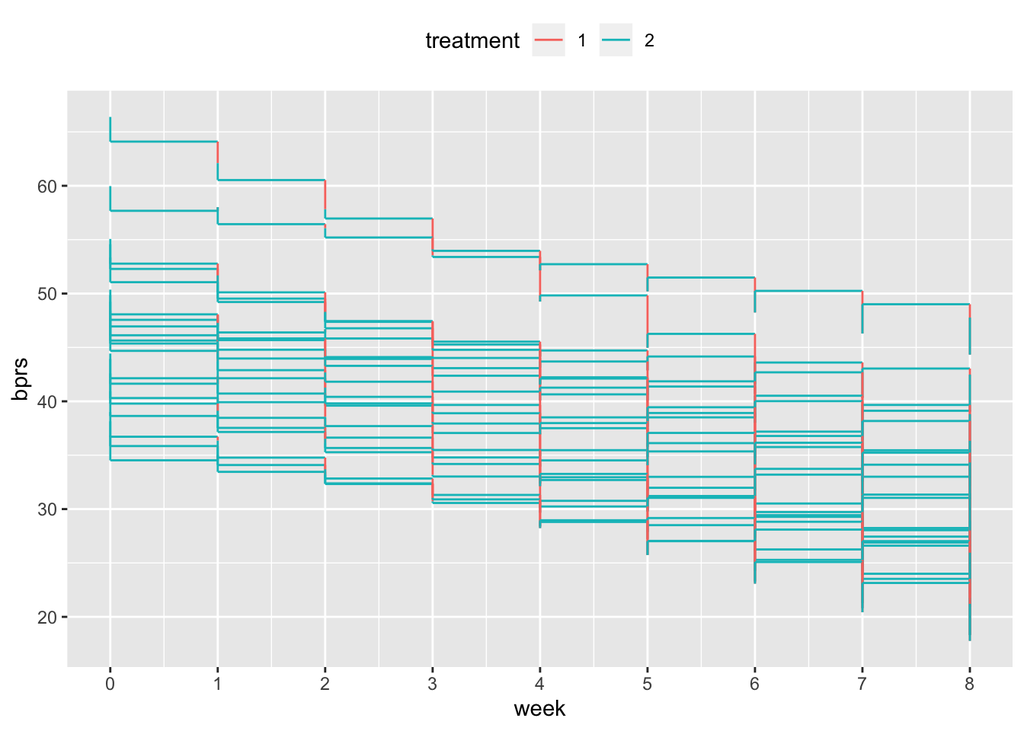

```r
ggplot(data = BPRSL) +
  geom_step(aes(x = week, y = Fitted, group = subject, color = treatment)) +
  scale_x_continuous(name = "week", breaks = seq(0, 8)) +
  scale_y_continuous(name = "bprs") +
  theme(legend.position = "top")
```

At first I tried the same code as I tried to used before, but the same error occured. Then I changed the code to geom_step, after that I could draw the picture but i don’t know how to explain it.

##So this is the end of my results. I had hughe difficulties this week and I think I did a better job with the RATS data than with this BPRS data, but at least I tried. Hope that the peer reviewers can understand some of this.

```r
library(magrittr)
```